# Activity 7: Leading your own data analysis

#### *ENVST 206: Environmental Data Science, Hamilton College*

## Instructions

There are 8 questions to this activity. Save your answers in word document that you will hand in on Blackboard using a .pdf or .docx extension. Save your file with your last name first in the filename to help me keep track of files for grading. Keep your script file in your GitHub folder and make sure that all changes are pushed to GitHub. Code for all questions should be clearly commented with the question number. You will include a link to your script file as a part of your final question in this activity. The assignment is worth 30 points. Include any plots you make for a question in your answers.

## Learning objectives

#### 1. Learn to work with data independently

#### 2. Formulate an objective and outcomes for your analysis

#### 3. Get started on your class project so that you can get feedback

You will answer the following questions and turn in your R script as you begin to work with data for your course project this week. You may find a full description of the course project expectations and suggested datasets on Blackboard. Answer the following questions to communicate your directions and focus for your project.

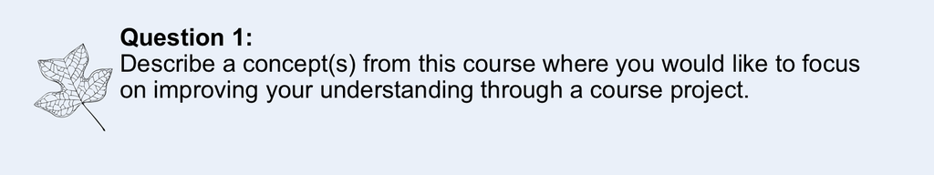

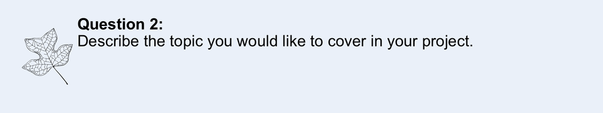

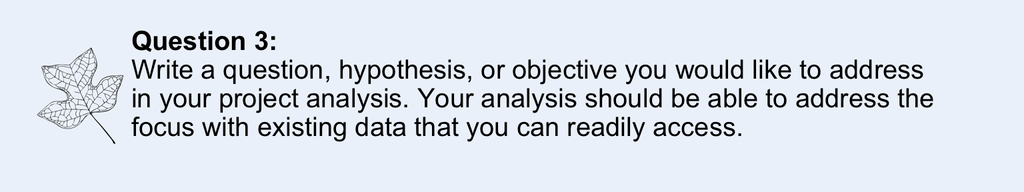

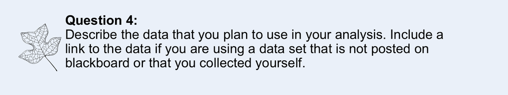

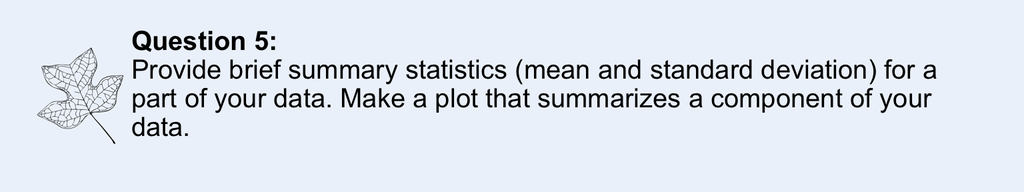

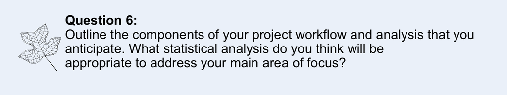

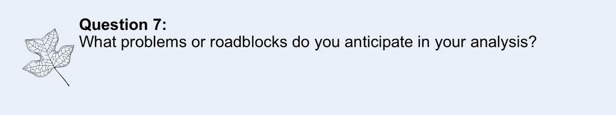

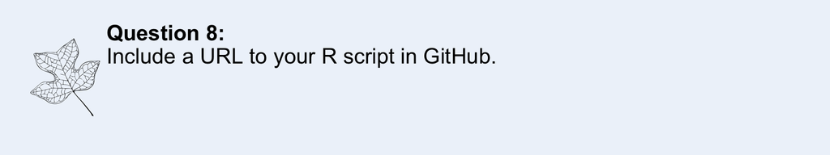